# Introduction

Author: Chao Li (cl1486)

Dataset: Crypto_quotes_with_change_label.csv

```
Features: various technical indicators including "EMA","MACD" and so on.

Label: the past one month quotes change, including "High position", "Middle" and "Low position"
```

# Packages

```python
import pandas as pd
import numpy as np
import matplotlib.pyplot as plt

from sklearn import preprocessing
from sklearn.model_selection import train_test_split
from sklearn.ensemble import RandomForestClassifier
from sklearn.metrics import classification_report
from sklearn.metrics import confusion_matrix
from sklearn import tree
```

# Data review

```python
ori_data = pd.read_csv('Crypto_quotes_with_change_label.csv', index_col=0)

ori_data.head()
```

| token | BBANDS_upperband | BBANDS_middleband | BBANDS_lowerband | DEMA | EMA | HT_TRENDLINE | macd | macdsignal | macdhist | mfi | ... | ad | adosc | obv | atr | natr | trange | EMA-trend | MACD-position | MACD-indicator | Quotes_label |
| --- | --- | --- | --- | --- | --- | --- | --- | --- | --- | --- | --- | --- | --- | --- | --- | --- | --- | --- | --- | --- | --- |
| BTCUSDT | 0.362322 | 0.361992 | 0.367133 | 0.649796 | 0.476603 | 0.684001 | 0.491082 | 0.494432 | 0.506317 | 0.399946 | ... | 0.951831 | 0.481494 | 0.366103 | 0.214097 | 0.178244 | 0.151610 | Up trend | sell | low | High position |
| ETHUSDT | 0.489594 | 0.511084 | 0.502709 | 0.653345 | 0.826105 | 0.704747 | 0.142334 | 0.165321 | 0.608019 | 0.331334 | ... | 0.968939 | 0.257905 | 0.806731 | 0.326164 | 0.184263 | 0.106257 | Up trend | sell | low | Middle |
| BNBUSDT | 0.229414 | 0.192204 | 0.223952 | 0.431558 | 0.318604 | 0.491981 | 0.365145 | 0.317297 | 0.766872 | 0.348333 | ... | 0.996346 | 0.394041 | 0.358931 | 0.171564 | 0.091356 | 0.052739 | Up trend | sell | low | Middle |
| NEOUSDT | 0.094165 | 0.107352 | 0.124070 | 0.387119 | 0.182593 | 0.293207 | 0.298248 | 0.265877 | 0.721418 | 0.253389 | ... | 0.942659 | 0.139290 | 0.754360 | 0.097001 | 0.113505 | 0.023239 | Up trend | sell | low | Middle |
| LTCUSDT | 0.107873 | 0.126731 | 0.146753 | 0.465039 | 0.197860 | 0.355040 | 0.344851 | 0.366748 | 0.660535 | 0.160331 | ... | 0.674796 | 0.311130 | 0.039643 | 0.140491 | 0.134167 | 0.041636 | Up trend | sell | low | Middle |

5 rows × 27 columns

```python
ori_data['Quotes_label'].value_counts()
```

```
Low position     66
Middle           61
High position    46
Name: Quotes_label, dtype: int64
```

# EDA and data processing

## data cleanning

```python
# drop null value
ori_data = ori_data.dropna()

# get dummy varibables
dum_df = pd.get_dummies(ori_data, columns=[
                        'EMA-trend', 'MACD-position', 'MACD-indicator'], drop_first=True)

# label processing
le = preprocessing.LabelEncoder()
dum_df['Quotes_label'] = le.fit_transform(dum_df['Quotes_label'])
```

## train-test split

```python
X = dum_df.iloc[:, dum_df.columns != 'Quotes_label']
y = dum_df['Quotes_label']

# Train-test split
X_train, X_test, y_train, y_test = train_test_split(X, y, random_state=0)
```

# Random forest

## Model training

```python
clf = RandomForestClassifier(class_weight='balanced', random_state=0)
# the balanced means the large lag between the 1 and 0, e.g. only 2 of 1 but 998 of 0.
clf.fit(X_train, y_train)
```

```
RandomForestClassifier(class_weight='balanced', random_state=0)
```

```python
trees = clf.estimators_[:9]
```

## Visualization

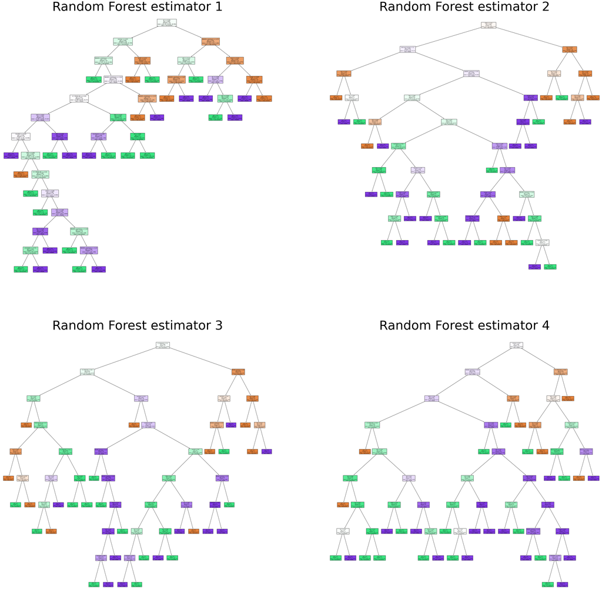

```python
fig = plt.figure(figsize=(60, 60))

for i in range(4):
    plt.subplot(2, 2, i+1)
    tree.plot_tree(trees[i], feature_names=X_train.columns,
                   class_names=le.classes_, filled=True)
    plt.title(f"Random Forest estimator {i+1}", fontsize=70)

plt.show()
fig.savefig("Random Forest.png")
```

## Confusion matrix and evaluation

```python
# make prediction
y_pred = clf.predict(X_test)

# print out prediction results
print('Report:\n')
print(classification_report(y_test, y_pred))
print('Confusion Matrix:\n')
print(confusion_matrix(y_test, y_pred))
```

```
Report:

              precision    recall  f1-score   support

           0       0.75      0.60      0.67        10
           1       0.67      0.30      0.41        20
           2       0.42      0.85      0.56        13

    accuracy                           0.53        43
   macro avg       0.61      0.58      0.55        43
weighted avg       0.61      0.53      0.52        43

Confusion Matrix:

[[ 6  2  2]
 [ 1  6 13]
 [ 1  1 11]]
```

## Feature importance

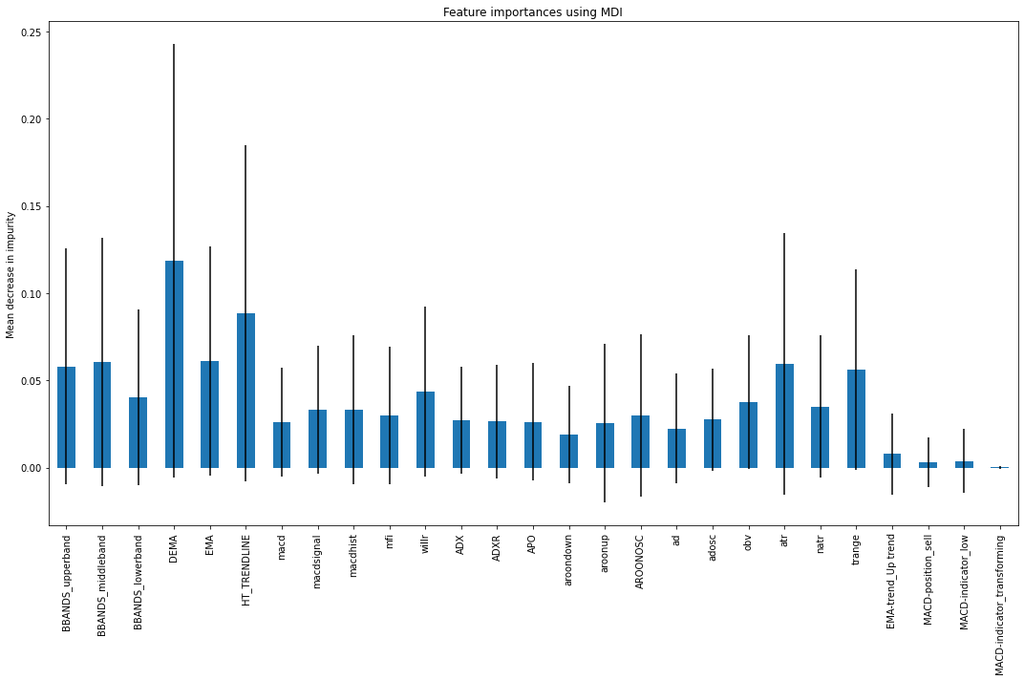

```python
feature_names = X.columns

importances = clf.feature_importances_

forest_importances = pd.Series(importances, index=feature_names)
std = np.std([tree.feature_importances_ for tree in clf.estimators_], axis=0)


fig, ax = plt.subplots(figsize=(15, 10))
forest_importances.plot.bar(yerr=std, ax=ax)
ax.set_title("Feature importances using MDI")
ax.set_ylabel("Mean decrease in impurity")
fig.tight_layout()
```

## Model discussion and analysis

After printing several estimators under the random forest, the tree structure of these estimators is not complex, where it conforms to the major ideal of random forest, using the simple tree to vote the final prediction.

One guessed the reason for the high prediction precision on the "High position" and "Low position" is that there is a distinct difference between each quote condition. For example, all the coin in the high position has a similar technical indicator.

# Conclusion

```
This random forest result supports the application of using ML to predict or identify the market quotes.
```

This means that, some technical indicators are useful to help identify the position of the current quotes, according to the random forest result, such as "DEMA" and "HT_TrendLine". Especially, from the above result, "DEMA" is one of the most important technical indicators when recognizing the position of the current quotes.